# Biodiversity across a salinity gradient

Mar Schmidt

March 26, 2025

# Goals

This analysis builds a biodiversity analysis off of the Hill Numbers, which is discussed in a paper entitled “[A conceptual guide to measuring species diversity” by Roswell et al., 2021 in Oikos](https://nsojournals.onlinelibrary.wiley.com/doi/epdf/10.1111/oik.07202). (A great paper!)

1. Calculate the Hill Diversity of the samples using the [iNEXT package](https://besjournals.onlinelibrary.wiley.com/doi/full/10.1111/2041-210X.12613).
2. Evaluate the interpolated and extrapolated rarefaction curves.
3. Evaluate the diversity values.
4. Makes notes of specific samples and their seq depth.
5. Plot various biodiversity metrics across the salinity gradient to *test the scientific question below!* (Remember, we’re doing science!)
1. We will need the `phytree_preprocessed_physeq`, which includes a rooted tree (ideally within the archaea) that we created in `analysis/04B_Phylogenetic_Tree_Inspection.Rmd`.

## Outputs

*This is an exciting analysis!!! We finally get to answer one of our scientific questions!*

1. Calculated biodiversity measure across the samples.
2. Figures to include in our scientific paper that visualize the data across the scientific question.
3. Statistical tests conveying the message of our scientific question.

# Scientific Question

## Field site background

### Mission-Aransas NERR

Remember what we were doing before we got all distracted with the details of ASVs, pre-processing, and phylogenetics? We actually conducted a study to evaluate the role that salinity plays in shaping Estuarine Microbial Communities in the Gulf of Mexico at the long-term SWMP stations at the [Mission-Aransas National Estuarine Research Reserve (NERR)](https://marinescience.utexas.edu/research/mission-aransas-reserve#:~:text=The%20Mission%2DAransas%20National%20Estuarine%20Research%20Reserve%20is%20a%20federal,of%20Texas%20Marine%20Science%20Institute).

**What’s a NERR?** The [National Oceanic and Atmospheric Administration (NOAA) maintains 30 estuarine research reserves across the country](https://coast.noaa.gov/nerrs/). There are 5 in the Gulf of Mexico, two (soon to be three!) in the Great Lakes, among others across the United States!

## Question & Hypotheses

How is microbial biodiversity modified across a salinity gradient?

- *Null Hypothesis:* Microbial biodiversity (*e.g.* richness) does not vary along a salinity gradient.
- *Alternative Hypothesis:* Microbial biodiversity (*e.g.* richness) will increase as salt concentration lowers. There is an inverse relationship between richness and salinity.

*Let’s get to calculating Biodiversity!*

# Before starting

## Timing of this script

```r
# What time did we start running this script?
start_time <- Sys.time()
```

## Set the seed

```r
# Any number can be chosen
set.seed(238428)
```

## Load Packages & Colors

```r
# install ggpubr
#if(!require(devtools)) install.packages("devtools")
#devtools::install_github("kassambara/ggpubr")

# Efficiently load packages
pacman::p_load(tidyverse, devtools, patchwork, iNEXT, phyloseq, ggpubr,
               install = FALSE)

# Load in colors for plotting between different files
source("code/colors.R")
```

## Load Data files

```r
# Preprocessed phyloseq object: With the phylogenetic tree!
load("data/04_PhylogeneticTree/phytree_preprocessed_physeqs.RData")

archaeal_rooted_physeq
```

```
## phyloseq-class experiment-level object
## otu_table()   OTU Table:         [ 2605 taxa and 89 samples ]
## sample_data() Sample Data:       [ 89 samples by 43 sample variables ]
## tax_table()   Taxonomy Table:    [ 2605 taxa by 9 taxonomic ranks ]
## phy_tree()    Phylogenetic Tree: [ 2605 tips and 2604 internal nodes ]
```

```r
# Intiution Check
min(sample_sums(archaeal_rooted_physeq))
```

```
## [1] 1576
```

```r
# Make metadata dataframe
metadata_df <-
  archaeal_rooted_physeq %>%
  sample_data() %>%
  data.frame()

# Take a look!
head(metadata_df)
```

```
##                   year day project     station depth replicate fraction   date
## 20210602-MA-ABB1F 2021  02      MA Aransas Bay   2.5         1     Free 6/2/21
## 20210602-MA-ABB1P 2021  02      MA Aransas Bay   2.5         1 Particle 6/2/21
## 20210602-MA-ABB1W 2021  02      MA Aransas Bay   2.5         1    Whole 6/2/21
## 20210602-MA-ABS1F 2021  02      MA Aransas Bay   0.0         1     Free 6/2/21
## 20210602-MA-ABS1P 2021  02      MA Aransas Bay   0.0         1 Particle 6/2/21
## 20210602-MA-ABS1W 2021  02      MA Aransas Bay   0.0         1    Whole 6/2/21
##                   month vol_filtered_mL DNA_conc1a_nguL total_uL_DNA tot_ng
## 20210602-MA-ABB1F  June             360           25.90        44.61   1207
## 20210602-MA-ABB1P  June             360            2.91        34.00    105
## 20210602-MA-ABB1W  June             360           65.30        43.36   2962
## 20210602-MA-ABS1F  June             300           39.70        44.94   1864
## 20210602-MA-ABS1P  June             300           10.40        42.54    463
## 20210602-MA-ABS1W  June             300           47.40        45.11   2233
##                   tot_filtration_time collection_time process_time sitting_time
## 20210602-MA-ABB1F                  20        08:30:00     17:30:00     09:00:00
## 20210602-MA-ABB1P                  20        08:30:00     17:30:00     09:00:00
## 20210602-MA-ABB1W                  20        08:30:00     17:30:00     09:00:00
## 20210602-MA-ABS1F                  20        08:30:00     16:45:00     08:15:00
## 20210602-MA-ABS1P                  20        08:30:00     16:45:00     08:15:00
## 20210602-MA-ABS1W                  20        08:30:00     16:45:00     08:15:00
##                   julian_day total_filter used_filter filter_left X10min_65
## 20210602-MA-ABB1F        153            1         1.0         0.0        no
## 20210602-MA-ABB1P        153            1         1.0         0.0        no
## 20210602-MA-ABB1W        153            1         1.0         0.0        no
## 20210602-MA-ABS1F        153            1         0.5         0.5       yes
## 20210602-MA-ABS1P        153            1         0.5         0.5       yes
## 20210602-MA-ABS1W        153            1         0.5         0.5       yes
##                      dna_kit vol_DNAused_16S vol_qPCR     labnote_page
## 20210602-MA-ABB1F July26_kit            1.39        2 spilled filtrate
## 20210602-MA-ABB1P July26_kit           12.00        2 spilled filtrate
## 20210602-MA-ABB1W July26_kit            0.64        2             <NA>
## 20210602-MA-ABS1F July26_kit            1.06        2             <NA>
## 20210602-MA-ABS1P July26_kit            3.46        2             <NA>
## 20210602-MA-ABS1W July26_kit            0.89        2             <NA>
##                   Sample_or_Control     time water_tempC SpCond_mS salinity_psu
## 20210602-MA-ABB1F       True Sample 07:39:00       27.18     27.70        16.97
## 20210602-MA-ABB1P       True Sample 07:39:00       27.18     27.70        16.97
## 20210602-MA-ABB1W       True Sample 07:39:00       27.18     27.70        16.97
## 20210602-MA-ABS1F       True Sample 07:39:00       26.93     27.11        16.58
## 20210602-MA-ABS1P       True Sample 07:39:00       26.93     27.11        16.58
## 20210602-MA-ABS1W       True Sample 07:39:00       26.93     27.11        16.58
##                     pH turbidity_NTU chlorophyll_ugL percent_DO DO_mgL notes
## 20210602-MA-ABB1F 8.07          10.9             8.7      105.3   7.62  <NA>
## 20210602-MA-ABB1P 8.07          10.9             8.7      105.3   7.62  <NA>
## 20210602-MA-ABB1W 8.07          10.9             8.7      105.3   7.62  <NA>
## 20210602-MA-ABS1F 8.06           6.2             8.6      104.5   7.58  <NA>
## 20210602-MA-ABS1P 8.06           6.2             8.6      104.5   7.58  <NA>
## 20210602-MA-ABS1W 8.06           6.2             8.6      104.5   7.58  <NA>
##                               names denoisedF denoisedR merged nochim num_ASVs
## 20210602-MA-ABB1F 20210602-MA-ABB1F      4451      4391   4226   3534      145
## 20210602-MA-ABB1P 20210602-MA-ABB1P      4082      4052   3737   3183      141
## 20210602-MA-ABB1W 20210602-MA-ABB1W      6496      6481   6106   5053      157
## 20210602-MA-ABS1F 20210602-MA-ABS1F      4233      4242   3960   3249      128
## 20210602-MA-ABS1P 20210602-MA-ABS1P      4685      4709   4423   3808      150
## 20210602-MA-ABS1W 20210602-MA-ABS1W      5652      5690   5316   4437      144
```

# Biodiversity Hill Numbers with iNEXT

Next, we will calculate the biodiversity with the [iNEXT package](https://besjournals.onlinelibrary.wiley.com/doi/full/10.1111/2041-210X.12613) package. iNEXT focuses on three measures of biodiversity via the Hill numbers. Hill numbers have the order q:

1. **Species richness** when q = 0.
2. **Shannon diversity** when q = 1, representing the exponential of Shannon entropy.
3. **Simpson diversity** when q = 2, also known as the Inverse Simpson Index.

For each diversity measure, [iNEXT package](https://besjournals.onlinelibrary.wiley.com/doi/full/10.1111/2041-210X.12613) uses the observed abundance of species within a sample to compute diversity estimates and the associated 95% confidence intervals for the following two types of rarefaction and extrapolation (R/E):

1. **Sample-size-based (or size-based) R/E curves**: iNEXT computes diversity estimates for rarefied and extrapolated samples up to an appropriate size (2x the total number of individuals/sequences in that sample). This type of sampling curve plots the diversity estimates with respect to sample size. 2.**Coverage‐based R/E curves:** iNEXT computes diversity estimates for rarefied and extrapolated samples based on a standardized level of sample completeness (as measured by sample coverage) up to an appropriate coverage value. This type of sampling curve plots the diversity estimates with respect to sample coverage. **NOTE: Coverage is inapplicable to DADA2 datasets, as they lack singletons** (this is also why we can’t use Amy Willis’s breakaway approach).

```r
# prepare input data
iNEXT_input_df <-
  archaeal_rooted_physeq %>%
  otu_table() %>%
  data.frame()

# Quick check
dim(iNEXT_input_df)
```

```
## [1] 2605   89
```

```r
iNEXT_input_df[1:5, 1:5]
```

```
##          X20210602.MA.ABB1F X20210602.MA.ABB1P X20210602.MA.ABB1W
## ASV_1971                  3                  0                  0
## ASV_2876                  0                  0                  0
## ASV_2326                  0                  2                  0
## ASV_2157                  0                  0                  0
## ASV_2378                  0                  0                  0
##          X20210602.MA.ABS1F X20210602.MA.ABS1P
## ASV_1971                  0                  0
## ASV_2876                  0                  0
## ASV_2326                  0                  0
## ASV_2157                  0                  0
## ASV_2378                  0                  0
```

```r
# Run iNEXT: Calculate the Hill Numbers
# Note that: Species in ROWS, Samples in COLUMNS
# Remember to set the seed!
#iNEXT_data <- iNEXT(iNEXT_input_df,
#                    q = c(0,1,2), datatype = "abundance")

# Save the file
#save(iNEXT_data, file = "data/05_Biodiversity/iNEXT_data.RData")
```

# Evaluate the Diversity!

iNEXT takes a long time to calculate, so here we are working with previously calculated iNEXT data.

*An important note:* We’ll be using the size_based output. Our lab has previously been suspicious of the Asymptotic Estimator. Therefore we will use the size_based approach here, with the caveat that we will very rigorously confirm that we’ve approached saturation for all of our samples!

Let’s load the samples and their iNEXT data!

```r
load("data/05_Biodiversity/iNEXT_data.RData")
str(iNEXT_data)
```

```
## List of 3
##  $ DataInfo:'data.frame':    89 obs. of  14 variables:
##   ..$ Assemblage: chr [1:89] "X20210602.MA.ABB1F" "X20210602.MA.ABB1P" "X20210602.MA.ABB1W" "X20210602.MA.ABS1F" ...
##   ..$ n         : num [1:89] 3430 2603 4784 3182 3190 ...
##   ..$ S.obs     : num [1:89] 137 118 140 120 133 127 133 119 141 126 ...
##   ..$ SC        : num [1:89] 1 1 1 1 1 1 1 1 1 1 ...
##   ..$ f1        : num [1:89] 0 0 0 0 0 0 0 0 0 0 ...
##   ..$ f2        : num [1:89] 4 18 11 11 11 8 7 11 9 10 ...
##   ..$ f3        : num [1:89] 12 9 9 6 11 5 5 5 9 3 ...
##   ..$ f4        : num [1:89] 7 8 9 4 8 7 5 8 5 5 ...
##   ..$ f5        : num [1:89] 8 4 7 10 3 9 6 6 6 8 ...
##   ..$ f6        : num [1:89] 8 8 4 9 6 2 7 4 6 3 ...
##   ..$ f7        : num [1:89] 2 5 6 5 10 5 3 5 6 7 ...
##   ..$ f8        : num [1:89] 3 3 3 4 6 7 2 3 5 7 ...
##   ..$ f9        : num [1:89] 8 2 5 2 6 4 6 5 3 3 ...
##   ..$ f10       : num [1:89] 6 5 7 4 1 5 6 5 10 5 ...
##  $ iNextEst:List of 2
##   ..$ size_based    :'data.frame':   10680 obs. of  10 variables:
##   .. ..$ Assemblage: chr [1:10680] "X20210602.MA.ABB1F" "X20210602.MA.ABB1F" "X20210602.MA.ABB1F" "X20210602.MA.ABB1F" ...
##   .. ..$ m         : num [1:10680] 1 191 381 572 762 ...
##   .. ..$ Method    : chr [1:10680] "Rarefaction" "Rarefaction" "Rarefaction" "Rarefaction" ...
##   .. ..$ Order.q   : num [1:10680] 0 0 0 0 0 0 0 0 0 0 ...
##   .. ..$ qD        : num [1:10680] 1 72.3 97.8 111.1 119 ...
##   .. ..$ qD.LCL    : num [1:10680] 1 71.1 96.3 109.3 117 ...
##   .. ..$ qD.UCL    : num [1:10680] 1 73.5 99.3 112.9 121 ...
##   .. ..$ SC        : num [1:10680] 0.0454 0.8063 0.9081 0.9477 0.9669 ...
##   .. ..$ SC.LCL    : num [1:10680] 0.0414 0.8021 0.9045 0.945 0.965 ...
##   .. ..$ SC.UCL    : num [1:10680] 0.0495 0.8105 0.9117 0.9505 0.9688 ...
##   ..$ coverage_based:'data.frame':   5073 obs. of  8 variables:
##   .. ..$ Assemblage: chr [1:5073] "X20210602.MA.ABB1F" "X20210602.MA.ABB1F" "X20210602.MA.ABB1F" "X20210602.MA.ABB1F" ...
##   .. ..$ SC        : num [1:5073] 0.0454 0.8063 0.9081 0.9477 0.9669 ...
##   .. ..$ m         : num [1:5073] 1 191 381 572 762 ...
##   .. ..$ Method    : chr [1:5073] "Rarefaction" "Rarefaction" "Rarefaction" "Rarefaction" ...
##   .. ..$ Order.q   : num [1:5073] 0 0 0 0 0 0 0 0 0 0 ...
##   .. ..$ qD        : num [1:5073] 1 72.3 97.8 111.1 119 ...
##   .. ..$ qD.LCL    : num [1:5073] 0.962 70.492 95.652 108.635 116.414 ...
##   .. ..$ qD.UCL    : num [1:5073] 1.04 74.18 99.94 113.54 121.62 ...
##  $ AsyEst  :'data.frame':    267 obs. of  7 variables:
##   ..$ Assemblage: chr [1:267] "X20210602.MA.ABB1F" "X20210602.MA.ABB1F" "X20210602.MA.ABB1F" "X20210602.MA.ABB1P" ...
##   ..$ Diversity : chr [1:267] "Species richness" "Shannon diversity" "Simpson diversity" "Species richness" ...
##   ..$ Observed  : num [1:267] 137 57.9 21.9 118 49.4 ...
##   ..$ Estimator : num [1:267] 137 59 22 118 50.5 ...
##   ..$ s.e.      : num [1:267] 2.02 1.53 1.03 3.5 1.14 ...
##   ..$ LCL       : num [1:267] 137 56 20 118 48.3 ...
##   ..$ UCL       : num [1:267] 141 62 24 124.9 52.7 ...
##  - attr(*, "class")= chr "iNEXT"
```

```r
typeof(iNEXT_data)
```

```
## [1] "list"
```

# Plot Diversity

```r
# Prepare Colors
color_df <-
  iNEXT_input_df %>%
  colnames() %>%
  data.frame()
# Check
head(color_df)
```

```
##                    .
## 1 X20210602.MA.ABB1F
## 2 X20210602.MA.ABB1P
## 3 X20210602.MA.ABB1W
## 4 X20210602.MA.ABS1F
## 5 X20210602.MA.ABS1P
## 6 X20210602.MA.ABS1W
```

```r
# Rename the column
colnames(color_df)[1] <- "names"
# Check
head(color_df)
```

```
##                names
## 1 X20210602.MA.ABB1F
## 2 X20210602.MA.ABB1P
## 3 X20210602.MA.ABB1W
## 4 X20210602.MA.ABS1F
## 5 X20210602.MA.ABS1P
## 6 X20210602.MA.ABS1W
```

```r
# Make a helper dataframe for plotting with colors
iNEXT_color_df <-
  color_df %>%
  # Fix the names for merging
  mutate(names = gsub(names, pattern = "[.]", replace = "-"),
         names = gsub(names, pattern = "X",  replace = "")) %>%
  # Merge with metadata
  left_join(metadata_df, by = "names") %>%
  # Merge with colors for plotting with ggiNEXT
  left_join(data.frame(station_colors = station_colors,
            station = names(station_colors)),
            by = "station")
```

# Plot Rarefaction with `ggiNEXT`

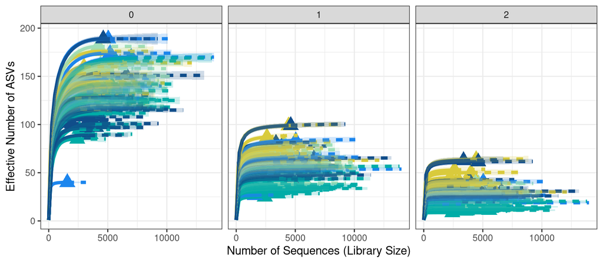

```r
# Plot rarefaction!
# rarefaction/extrapolation curve, type = 1

# Order q:
  # 0 = Richness/ Number of Total taxa
  # 1 = Exponential Shannon / Number of "Common" taxa
  # 2 = Inverse Simpson / Number of "Dominant" taxa

ggiNEXT(iNEXT_data, type = 1, facet.var = "Order.q") +
  facet_wrap(~Order.q, scales = "fixed") +
  scale_color_manual(values = iNEXT_color_df$station_colors, guide = FALSE) +
  scale_fill_manual(values = iNEXT_color_df$station_colors, guide = FALSE) +
  scale_shape_manual(values = base::rep(17, nsamples(archaeal_rooted_physeq)),
                     guide = FALSE) +
  labs(x = "Number of Sequences (Library Size)",
       y = "Effective Number of ASVs") +
  theme_bw() +
  theme(legend.position = "none")
```

Remembering that an Order q of:

- 0 = Richness/ Number of Total taxa
- 1 = Exponential Shannon / Number of “Common” taxa
- 2 = Inverse Simpson / Number of “Dominant” taxa

*Also note that iNEXT will extrapolate the number of sequences to double the sequencing depth of the sample!*

Ok, this plot is nice, but since it’s autogenerated with the `ggiNEXT` function, I’d like some more freedom to plot. Let’s manually plot the data that we pull out from the iNEXT data.

# Manually plot Diversity

## Rarefaction

```r
iNEXT_manual_df <-
  iNEXT_data$iNextEst$size_based %>%
  dplyr::rename(names = Assemblage) %>%
  # Fix the samples names
  mutate(names = gsub(names, pattern = "[.]", replace = "-"),
         names = gsub(names, pattern = "X", replace = "")) %>%
  # join with metadata
  left_join(., metadata_df, by = "names") %>%
  # Add colors to data frame
  left_join(., data.frame(station_colors = station_colors,
                          station = names(station_colors)),
            by = "station") %>%
  mutate(station = factor(station, levels = c("Copano West", "Copano East",
                                              "Mesquite Bay", "Aransas Bay",
                                              "Shipping Channel")))
# Inspect
dim(iNEXT_manual_df)
```

```
## [1] 10680    53
```

```r
str(iNEXT_manual_df)
```

```
## 'data.frame':    10680 obs. of  53 variables:
##  $ names              : chr  "20210602-MA-ABB1F" "20210602-MA-ABB1F" "20210602-MA-ABB1F" "20210602-MA-ABB1F" ...
##  $ m                  : num  1 191 381 572 762 ...
##  $ Method             : chr  "Rarefaction" "Rarefaction" "Rarefaction" "Rarefaction" ...
##  $ Order.q            : num  0 0 0 0 0 0 0 0 0 0 ...
##  $ qD                 : num  1 72.3 97.8 111.1 119 ...
##  $ qD.LCL             : num  1 71.1 96.3 109.3 117 ...
##  $ qD.UCL             : num  1 73.5 99.3 112.9 121 ...
##  $ SC                 : num  0.0454 0.8063 0.9081 0.9477 0.9669 ...
##  $ SC.LCL             : num  0.0414 0.8021 0.9045 0.945 0.965 ...
##  $ SC.UCL             : num  0.0495 0.8105 0.9117 0.9505 0.9688 ...
##  $ year               : chr  "2021" "2021" "2021" "2021" ...
##  $ day                : chr  "02" "02" "02" "02" ...
##  $ project            : chr  "MA" "MA" "MA" "MA" ...
##  $ station            : Factor w/ 5 levels "Copano West",..: 4 4 4 4 4 4 4 4 4 4 ...
```

[output cut: 43 more lines]

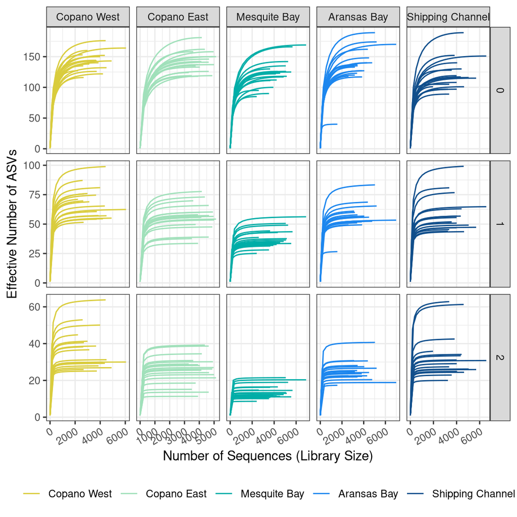

```r
# Plot it - Rarefaction Curve
iNEXT_manual_df %>%
  # Filter out rows that are calcaulted by rarefaction from iNEXT
  dplyr::filter(Method == "Rarefaction") %>%
  # Now, let's draw the plot, be sure to group by the samples if using geom_line!
  ggplot(aes(x = m, y= qD, color = station, group = names)) +
  geom_line() +
  # Facet with the station to see the samples better
  facet_grid(Order.q~station, scales = "free") +
  scale_color_manual(values = station_colors) +
  labs(x = "Number of Sequences (Library Size)",
       y = "Effective Number of ASVs") +
  theme_bw() +
  #guides(color = guide_legend(nrow = 2, byrow = TRUE)) +
  theme(legend.position = "bottom",
        axis.text.x = element_text(angle = 30, vjust = 1, hjust = 1),
        legend.title = element_blank())
```

While the rarefaction curves from `ggiNEXT` agglomerated the data together, it was hard to see individual samples. Above, we can start to tease apart specific samples within each station that appear higher.

**Some initial take-aways:**

- *Richness:*
  - There does not appear to be much difference between the stations in the total richness.
  - However, there does appear to be an outlier sample in Aransas Bay.
- *Simpson’s Diversity:*
  - The **Copano West station** has a bimodal distribution with (1) samples that tend to have more dominant taxa/higher diversity with 40-60 dominant species versus (2) samples that have lower diversity around 25-30 dominant taxa).
  - **Mesquite Bay** appears to have the lowest Simpson’s diversity as the plateau is mostly all below ~22 dominant taxa.
  - There are two samples in the **Shipping Channel** that have much larger Simpson Diversity values compared to other samples. I wonder who those are!
- *Shannon Diversity:*
  - Here, the trends that were starting to be witnessed in the Shannon diversity are much more amplified!

However, all of these changes are qualitative… let’s actually quantify by running some stats!

# Boxplots of Diversity

Now, let’s zoom in on a bit of a better view of the data by visualizing it in a boxplot…

```r
# Prettier station labels
station_names <- c("Copano\nWest", "Copano\nEast","Mesquite\nBay",
                   "Aransas\nBay", "Shipping\nChannel")

names(station_names) <- c("Copano West", "Copano East","Mesquite Bay",
                          "Aransas Bay", "Shipping Channel")

# Make a dataframe
obs_div_df <-
  iNEXT_manual_df %>%
  dplyr::filter(Method == "Observed") %>%
  left_join(data.frame(station_names = station_names,
                       station = names(station_names)),
                       by = "station") %>%
  mutate(station_names = factor(station_names,
                                levels = c("Copano\nWest", "Copano\nEast",
                                           "Mesquite\nBay", "Aransas\nBay",
                                           "Shipping\nChannel")))

# Check it
head(obs_div_df)
```

```
##               names    m   Method Order.q        qD    qD.LCL    qD.UCL SC
## 1 20210602-MA-ABB1F 3430 Observed       0 137.00000 134.52209 139.47791  1
## 2 20210602-MA-ABB1F 3430 Observed       1  57.85038  55.38666  60.31409  1
## 3 20210602-MA-ABB1F 3430 Observed       2  21.87891  20.03965  23.71816  1
## 4 20210602-MA-ABB1P 2603 Observed       0 118.00000 115.32931 120.67069  1
## 5 20210602-MA-ABB1P 2603 Observed       1  49.36022  47.21466  51.50577  1
## 6 20210602-MA-ABB1P 2603 Observed       2  22.54756  20.49137  24.60374  1
##      SC.LCL SC.UCL year day project     station depth replicate fraction   date
## 1 0.9988928      1 2021  02      MA Aransas Bay   2.5         1     Free 6/2/21
## 2 0.9988928      1 2021  02      MA Aransas Bay   2.5         1     Free 6/2/21
## 3 0.9988928      1 2021  02      MA Aransas Bay   2.5         1     Free 6/2/21
## 4 0.9980896      1 2021  02      MA Aransas Bay   2.5         1 Particle 6/2/21
## 5 0.9980896      1 2021  02      MA Aransas Bay   2.5         1 Particle 6/2/21
## 6 0.9980896      1 2021  02      MA Aransas Bay   2.5         1 Particle 6/2/21
##   month vol_filtered_mL DNA_conc1a_nguL total_uL_DNA tot_ng tot_filtration_time
```

[output cut: 41 more lines]

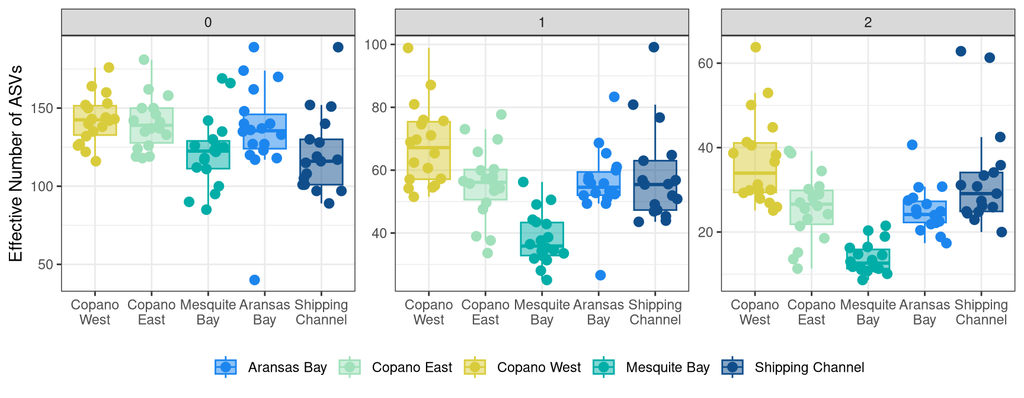

```r
# Boxplots by station
obs_div_df %>%
  ggplot(aes(x = station_names, y = qD, fill = station, color = station)) +
  facet_wrap(.~Order.q, scales = "free") +
  geom_jitter(size = 2.5) +
  geom_boxplot(alpha = 0.5, outlier.shape = NA) +
  scale_color_manual(values = station_colors) +
  scale_fill_manual(values = station_colors) +
  labs(y = "Effective Number of ASVs") +
  theme_bw() +
  theme(legend.position = "bottom",
        axis.title.x = element_blank(),
        legend.title = element_blank())
```

We can draw that:

- Richness doesn’t appear to be different between the stations, however, we might need to run a statistical test to check!
- **Mesquite Bay** appears to have the lowest Shannon and Simpson diversity, indicating that it has fewer common/dominant taxa compared to other communities.
- **Copano West** seems to have the highest Shannon and Simpson Diversity *and* the highest amount of variation. Though, we’d also need to follow this up with a test!

## Richness - Statistical Testing

```r
# Make a richness data frame
richness_df <-
  obs_div_df %>%
  dplyr::filter(Method == "Observed") %>%
  dplyr::filter(Order.q == 0)

# Add the statistical test!
kruskal.test(qD ~ station_names, data = richness_df)
```

```
##
##  Kruskal-Wallis rank sum test
##
## data:  qD by station_names
## Kruskal-Wallis chi-squared = 18.525, df = 4, p-value = 0.0009741
```

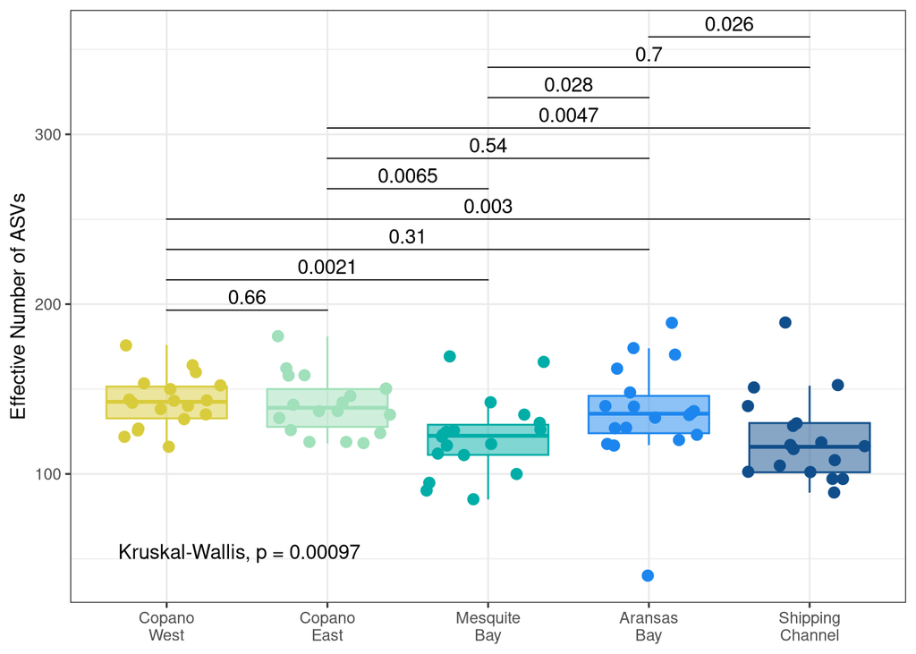

```r
#
my_comparisons <- list( c("Copano\nWest", "Copano\nEast"), c("Copano\nWest", "Mesquite\nBay"),
                        c("Copano\nWest", "Aransas\nBay"), c("Copano\nWest", "Shipping\nChannel"),
                        c("Copano\nEast", "Mesquite\nBay"), c("Copano\nEast", "Aransas\nBay"),
                        c("Copano\nEast", "Shipping\nChannel"), c("Mesquite\nBay", "Aransas\nBay"),
                        c("Mesquite\nBay", "Shipping\nChannel"), c("Aransas\nBay", "Shipping\nChannel"))

# Now, plot it!
richness_df %>%
  ggplot(aes(x = station_names, y = qD, fill = station, color = station)) +
  geom_jitter(size = 2.5) +
  geom_boxplot(alpha = 0.5, outlier.shape = NA) +
  scale_color_manual(values = station_colors) +
  scale_fill_manual(values = station_colors) +
  labs(y = "Effective Number of ASVs") +
  # Add pairwise comparisons p-value
  stat_compare_means(comparisons = my_comparisons,
                     tip.length = 0, hide.ns = TRUE) +
  stat_compare_means(label.y = 50)  +   # Add global p-value
  theme_bw() +
  theme(legend.position = "none",
        axis.title.x = element_blank(),
        legend.title = element_blank())
```

# Environmental Variable Check

```r
# Check out metadata
head(metadata_df)
```

```
##                   year day project     station depth replicate fraction   date
## 20210602-MA-ABB1F 2021  02      MA Aransas Bay   2.5         1     Free 6/2/21
## 20210602-MA-ABB1P 2021  02      MA Aransas Bay   2.5         1 Particle 6/2/21
## 20210602-MA-ABB1W 2021  02      MA Aransas Bay   2.5         1    Whole 6/2/21
## 20210602-MA-ABS1F 2021  02      MA Aransas Bay   0.0         1     Free 6/2/21
## 20210602-MA-ABS1P 2021  02      MA Aransas Bay   0.0         1 Particle 6/2/21
## 20210602-MA-ABS1W 2021  02      MA Aransas Bay   0.0         1    Whole 6/2/21
##                   month vol_filtered_mL DNA_conc1a_nguL total_uL_DNA tot_ng
## 20210602-MA-ABB1F  June             360           25.90        44.61   1207
## 20210602-MA-ABB1P  June             360            2.91        34.00    105
## 20210602-MA-ABB1W  June             360           65.30        43.36   2962
## 20210602-MA-ABS1F  June             300           39.70        44.94   1864
## 20210602-MA-ABS1P  June             300           10.40        42.54    463
## 20210602-MA-ABS1W  June             300           47.40        45.11   2233
##                   tot_filtration_time collection_time process_time sitting_time
## 20210602-MA-ABB1F                  20        08:30:00     17:30:00     09:00:00
## 20210602-MA-ABB1P                  20        08:30:00     17:30:00     09:00:00
## 20210602-MA-ABB1W                  20        08:30:00     17:30:00     09:00:00
## 20210602-MA-ABS1F                  20        08:30:00     16:45:00     08:15:00
## 20210602-MA-ABS1P                  20        08:30:00     16:45:00     08:15:00
## 20210602-MA-ABS1W                  20        08:30:00     16:45:00     08:15:00
##                   julian_day total_filter used_filter filter_left X10min_65
## 20210602-MA-ABB1F        153            1         1.0         0.0        no
## 20210602-MA-ABB1P        153            1         1.0         0.0        no
## 20210602-MA-ABB1W        153            1         1.0         0.0        no
## 20210602-MA-ABS1F        153            1         0.5         0.5       yes
## 20210602-MA-ABS1P        153            1         0.5         0.5       yes
## 20210602-MA-ABS1W        153            1         0.5         0.5       yes
##                      dna_kit vol_DNAused_16S vol_qPCR     labnote_page
## 20210602-MA-ABB1F July26_kit            1.39        2 spilled filtrate
## 20210602-MA-ABB1P July26_kit           12.00        2 spilled filtrate
## 20210602-MA-ABB1W July26_kit            0.64        2             <NA>
## 20210602-MA-ABS1F July26_kit            1.06        2             <NA>
## 20210602-MA-ABS1P July26_kit            3.46        2             <NA>
## 20210602-MA-ABS1W July26_kit            0.89        2             <NA>
##                   Sample_or_Control     time water_tempC SpCond_mS salinity_psu
## 20210602-MA-ABB1F       True Sample 07:39:00       27.18     27.70        16.97
## 20210602-MA-ABB1P       True Sample 07:39:00       27.18     27.70        16.97
## 20210602-MA-ABB1W       True Sample 07:39:00       27.18     27.70        16.97
## 20210602-MA-ABS1F       True Sample 07:39:00       26.93     27.11        16.58
## 20210602-MA-ABS1P       True Sample 07:39:00       26.93     27.11        16.58
## 20210602-MA-ABS1W       True Sample 07:39:00       26.93     27.11        16.58
##                     pH turbidity_NTU chlorophyll_ugL percent_DO DO_mgL notes
## 20210602-MA-ABB1F 8.07          10.9             8.7      105.3   7.62  <NA>
## 20210602-MA-ABB1P 8.07          10.9             8.7      105.3   7.62  <NA>
## 20210602-MA-ABB1W 8.07          10.9             8.7      105.3   7.62  <NA>
## 20210602-MA-ABS1F 8.06           6.2             8.6      104.5   7.58  <NA>
## 20210602-MA-ABS1P 8.06           6.2             8.6      104.5   7.58  <NA>
## 20210602-MA-ABS1W 8.06           6.2             8.6      104.5   7.58  <NA>
##                               names denoisedF denoisedR merged nochim num_ASVs
## 20210602-MA-ABB1F 20210602-MA-ABB1F      4451      4391   4226   3534      145
## 20210602-MA-ABB1P 20210602-MA-ABB1P      4082      4052   3737   3183      141
## 20210602-MA-ABB1W 20210602-MA-ABB1W      6496      6481   6106   5053      157
## 20210602-MA-ABS1F 20210602-MA-ABS1F      4233      4242   3960   3249      128
## 20210602-MA-ABS1P 20210602-MA-ABS1P      4685      4709   4423   3808      150
## 20210602-MA-ABS1W 20210602-MA-ABS1W      5652      5690   5316   4437      144
```

```r
# Pull out environmental variables
env_df <-
  metadata_df %>%
  dplyr::select(names, water_tempC:DO_mgL)

# Inspect
head(env_df)
```

```
##                               names water_tempC SpCond_mS salinity_psu   pH
## 20210602-MA-ABB1F 20210602-MA-ABB1F       27.18     27.70        16.97 8.07
## 20210602-MA-ABB1P 20210602-MA-ABB1P       27.18     27.70        16.97 8.07
## 20210602-MA-ABB1W 20210602-MA-ABB1W       27.18     27.70        16.97 8.07
## 20210602-MA-ABS1F 20210602-MA-ABS1F       26.93     27.11        16.58 8.06
## 20210602-MA-ABS1P 20210602-MA-ABS1P       26.93     27.11        16.58 8.06
## 20210602-MA-ABS1W 20210602-MA-ABS1W       26.93     27.11        16.58 8.06
##                   turbidity_NTU chlorophyll_ugL percent_DO DO_mgL
## 20210602-MA-ABB1F          10.9             8.7      105.3   7.62
## 20210602-MA-ABB1P          10.9             8.7      105.3   7.62
## 20210602-MA-ABB1W          10.9             8.7      105.3   7.62
## 20210602-MA-ABS1F           6.2             8.6      104.5   7.58
## 20210602-MA-ABS1P           6.2             8.6      104.5   7.58
## 20210602-MA-ABS1W           6.2             8.6      104.5   7.58
```

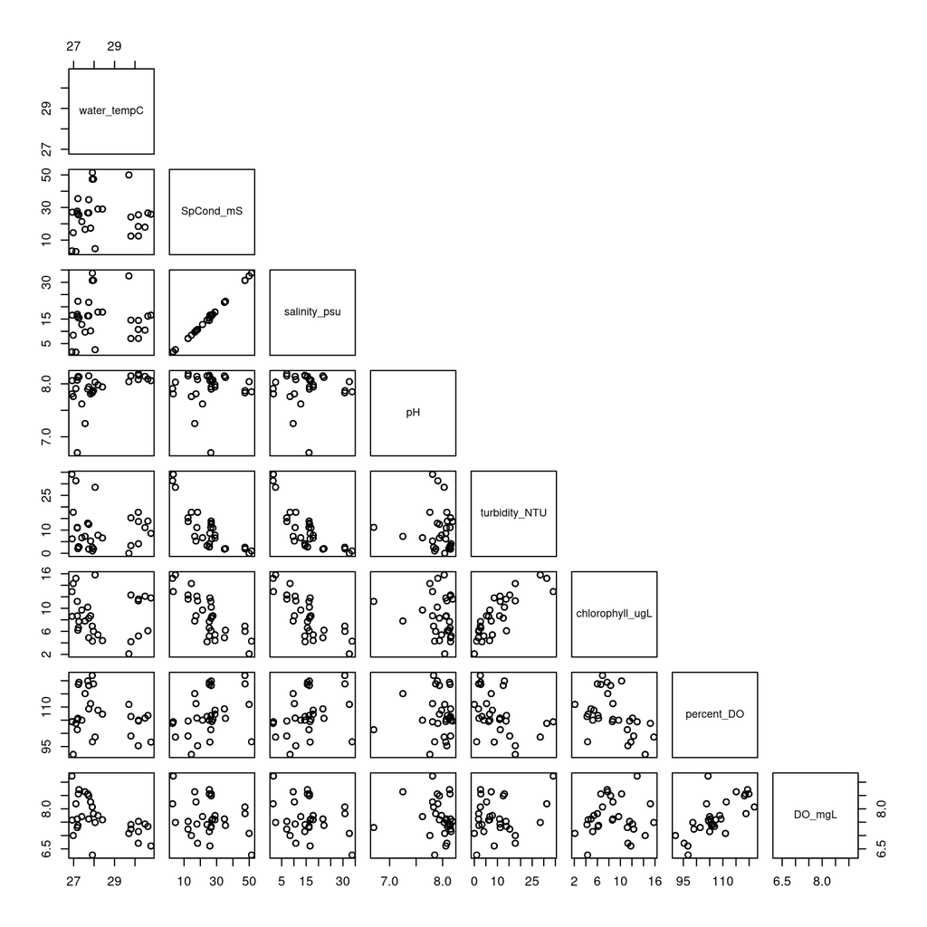

```r
# plot the correlations
pairs(dplyr::select(env_df, -names), upper.panel = NULL)
```

# Diversity vs Salinity

## Salinity - what is it?

PSU = practical salinity unit

- 1 PSU = 1 g of salt per 1,000 grams of water
- 1 PSU = 1 ppt (part per thousand)

The gradient is:

- Freshwater = 0-0.5
- Brackish = 0.5 - 30
- Marine = >30

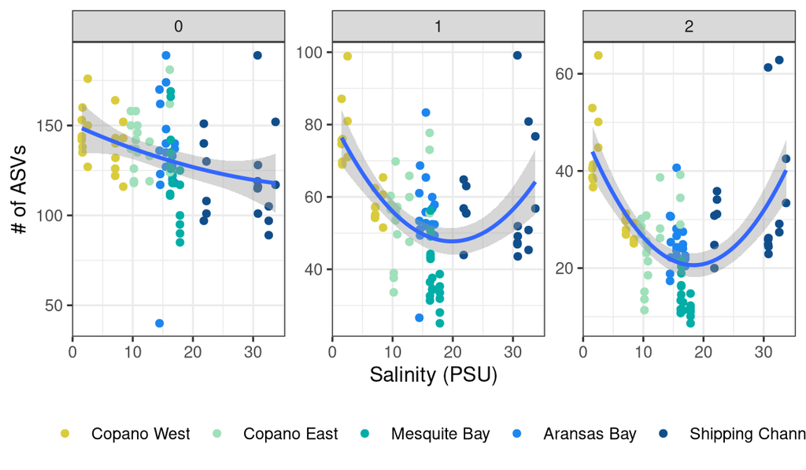

```r
# How does biodiversity change over the salinity gradient
iNEXT_manual_df %>%
  dplyr::filter(Method == "Observed") %>%
  ggplot(aes(x = salinity_psu, y = qD)) +
  facet_wrap(.~Order.q, scales = "free") +
  geom_point(aes(color = station)) +
  stat_smooth(method = "lm", formula = y ~poly(x, 2)) +
  labs(x = "Salinity (PSU)", y = "# of ASVs") +
  scale_color_manual(values = station_colors) +
  theme_bw() +
  theme(legend.position = "bottom",
        legend.title = element_blank())
```

Here, there appears to be a few different results:

- There appears to be a negative & linear relationship between salinity and Richness. This indicates that freshwaters have the highest number of ASVs (genearlly around ~150 ASVs) and as we gain more and more salt in the water, there are fewer species (closer to ~110 ASVs)! We will test this more below. :)
- Taking the Richness relationship above, we also need to note that there seems to be a high amount of variability within the brackish samples,
- Shannon & Simpson diversity appear to have a “U” shaped diversity curve!
- The “U” shape indicates that diversity measures that also weight relative abundance (common and dominant taxa) is highest at the two ends of the spectrum… this indicates that there are fewer dominant species in brackish waters.

### Explore Richness More

```r
# Make a richness data frame
richness_df <-
  obs_div_df %>%
  dplyr::filter(Method == "Observed") %>%
  dplyr::filter(Order.q == 0)

# Actually run the linear model
rich_vs_sal_lm <-
  lm(qD ~ salinity_psu, data = richness_df)

# Show me the model results
rich_vs_sal_lm
```

```
##
## Call:
## lm(formula = qD ~ salinity_psu, data = richness_df)
##
## Coefficients:
##  (Intercept)  salinity_psu
##      146.988        -0.955
```

```r
# Type?
class(rich_vs_sal_lm)
```

```
## [1] "lm"
```

```r
# Summary of lm
summary(rich_vs_sal_lm)
```

```
##
## Call:
## lm(formula = qD ~ salinity_psu, data = richness_df)
##
## Residuals:
##     Min      1Q  Median      3Q     Max
## -93.198 -12.951  -1.527  10.425  71.368
##
## Coefficients:
##              Estimate Std. Error t value Pr(>|t|)
## (Intercept)  146.9879     5.2655  27.915  < 2e-16 ***
## salinity_psu  -0.9550     0.3042  -3.139  0.00232 **
## ---
## Signif. codes:  0 '***' 0.001 '**' 0.01 '*' 0.05 '.' 0.1 ' ' 1
##
## Residual standard error: 23.25 on 87 degrees of freedom
## Multiple R-squared:  0.1017, Adjusted R-squared:  0.09141
## F-statistic: 9.853 on 1 and 87 DF,  p-value: 0.002315
```

In the output:

- **Coefficients** refer to the 𝛽’s
- **Estimate** is the estimate of each coefficient
- **Std. Error** is the standard error of the estimate
- **t value** is the coefficient divided by its standard error
- **Pr(>|t|)** is the p-value for the coefficient
- The **residual standard error** is the estimate of the variance of 𝜖
- **Degrees of freedom** is the sample size minus # of coefficients estimated
- **R-squared** is (roughly) the proportion of variance in the outcome explained by the model, instead we should always report the **adjusted R-squared**, which takes into penalizes the addition of unnecessary predictors, which provides a more accurate measure of model fit.
  - Note that the R-squared value will always increase/stay the same when you add more predictors, even if they are not relevant!
- The **F-statistic** compares the fit of the model as a whole to the null model (with no covariates)
  - When comparing models, we always want to take the model with the higher F-statistic because it indicates a stronger relationship between the predictor varaibles and the dependent variables, suggesting that the model is better.

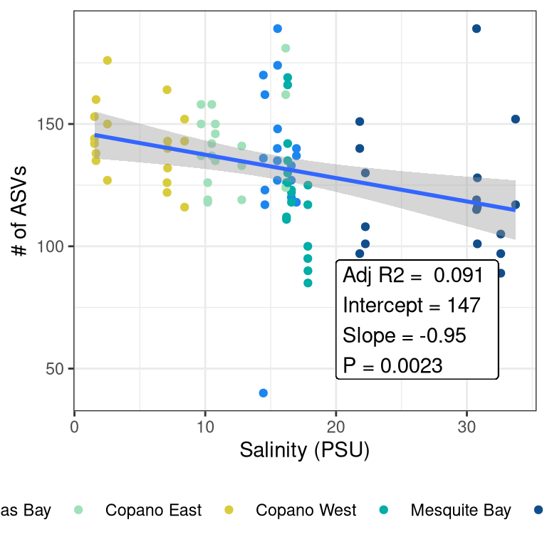

```r
richness_df %>%
  ggplot(aes(x = salinity_psu, y = qD)) +
  geom_point(aes(color = station)) +
  stat_smooth(method = "lm") +
  labs(x = "Salinity (PSU)", y = "# of ASVs") +
  scale_color_manual(values = station_colors) +
  theme_bw() +
  theme(legend.position = "bottom",
        legend.title = element_blank()) +
  geom_label(aes(x = 20, y = 70), hjust = 0,
             label = paste("Adj R2 = ",signif(summary(rich_vs_sal_lm)$adj.r.squared, 2),
                           "\nIntercept =",signif(rich_vs_sal_lm$coef[[1]],3),
                           " \nSlope =",signif(rich_vs_sal_lm$coef[[2]], 2),
                           " \nP =",signif(summary(rich_vs_sal_lm)$coef[2,4], 2)))
```

# Final info for Reproducibility

## Check Render Time

```r
# Take the time now that we are at the end of the script
end_time <- Sys.time()
end_time
```

```
## [1] "2025-03-26 13:48:02 EDT"
```

```r
# Echo the elapsed time
elapsed_time <- round((end_time - start_time), 3)
elapsed_time
```

```
## Time difference of 11.447 secs
```